# Quarto Demo

作者

Yoshinobu Ishizaki

公開

2022年5月17日

## 1 Quartoデモ

標準的なHTML文書出力のデモ。

**ヒント**

デフォルトでこのような注記スタイルを持っている。

note, tip, important, caution, warningの5種類がある。詳しくは https://quarto.org/docs/authoring/callouts.html 参照。

**内容を見るにはここを開く**

タイトルを付けて、最初はクローズした状態の物を作れる。 クイズ等のインターフェースに使える。

図や表、数式、セクション等へ統一的な書式で相互参照を付けられる。

次節のプロットへの参照例: 図 1 図 3 図 2

数式への参照 : 式 1 式 3

節への参照: セクション 5 セクション 4

## 2 YAML

このファイルの先頭に記載してあるYAMLヘッダは次の通り。

```
title: "Quarto Demo"
author: "Yoshinobu Ishizaki"
lang: ja
date: last-modified
date-formart: iso
toc: true
number-sections: true
format:
  html:
    self-contained: true
```

`date: last-modified`とすることで、ファイルの変更日付がセットされる。

`date-format: iso`とすることで、YYYY-MM-DD形式で日付表示。

`self-contained: true`とすると図等をファイル内部に収めてHTMLファイルのみでどの場所でも再現できるようになる。 指定しないと、`filename_files/`フォルダ以下に図などが配置され、HTMLファイル本体のみでは正しく表示されなくなる。

`theme: slate`のように様々なテーマが使える。使えるテーマはhttps://quarto.org/docs/output-formats/html-themes.htmlを参照。

## 3 R Code

```r
library(tidyverse)
Sys.setlocale(locale = "japanese")
```

`Sys.setlocale()`を`.qmd`ファイルの中で呼んでおくと、Rが正しく日本語ファイルや文字を扱ってくれる。 `.Renviron`や`.Rprofile`で初期設定として呼ぶとQuartoの変換時にエラーが起こる。

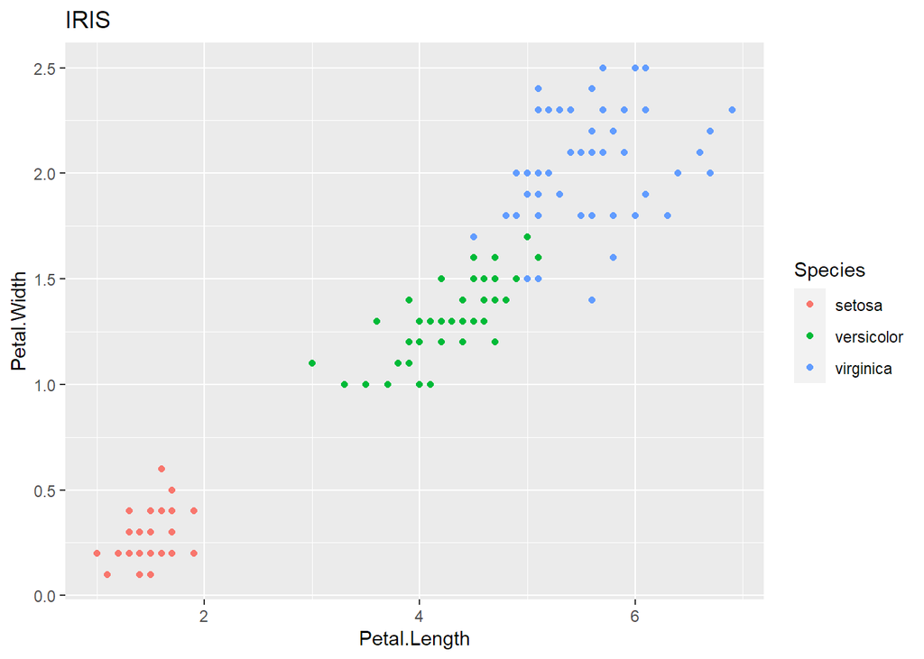

図 1: IRISプロット

```r
iris %>% ggplot(aes(x = Petal.Length, y = Petal.Width, color = Species)) +
  geom_point() +
  labs(title = "IRIS")
```

勿論日本語のタイトルや軸名も問題ない。

```r
library(palmerpenguins)
```

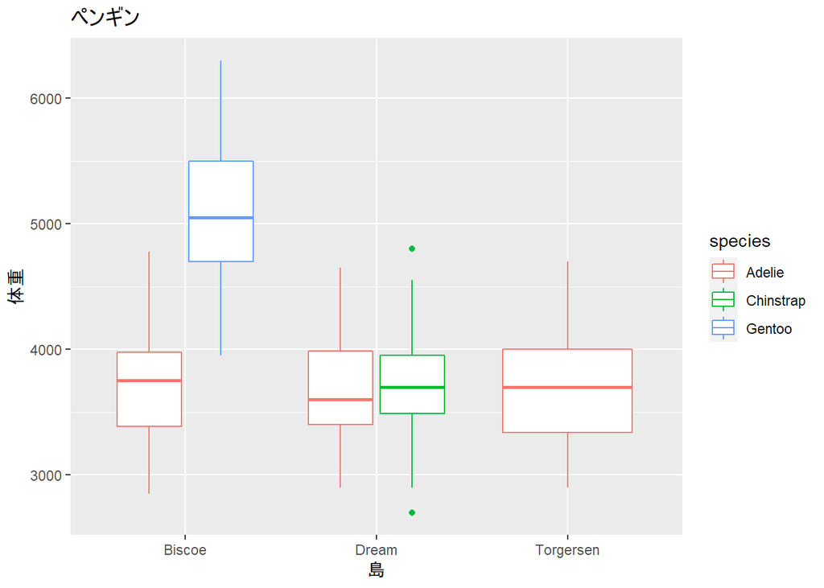

図 2: Palmer Penguines

```r
penguins %>%
  na.omit() %>%
  ggplot(aes(x = island, y = body_mass_g, color = species)) +
  geom_boxplot() +
  labs(title = "ペンギン", x = "島", y = "体重")
```

上記のプロットにて、以下のNAは予め除外した。

```r
penguins %>% filter(is.na(body_mass_g)) %>% knitr::kable()
```

| species | island | bill_length_mm | bill_depth_mm | flipper_length_mm | body_mass_g | sex | year |
| --- | --- | --- | --- | --- | --- | --- | --- |
| Adelie | Torgersen | NA | NA | NA | NA | NA | 2007 |
| Gentoo | Biscoe | NA | NA | NA | NA | NA | 2009 |

## 4 数式

オイラーの公式

$$e^{i \pi} = -1
\tag{1}$$

三角関数の公式

$$\begin{align}
\sin 2x & = 2 \sin x \cos x \\
\cos 2x & = \cos^2 x - \sin^2 x
\end{align}
\tag{2}$$

行列表現

$$\begin{pmatrix}
a & b & c \\
d & e & f \\
g & h & i \\
\end{pmatrix}^{T} =
\begin{pmatrix}
a & d & g \\
b & e & h \\
c & f & i
\end{pmatrix}
\tag{3}$$

## 5 図表

以下はMSOffice 付属の画像を使用した。

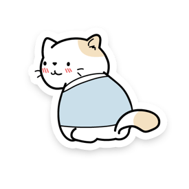

図 3: MS Cat1

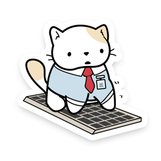

図 4: MS Cat2

図のレイアウトを簡単に指定できる。上の図を2列に配置。

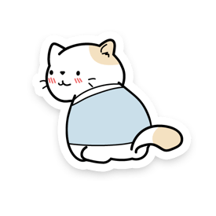

MS Cat1

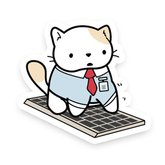

MS Cat2

図 5: 列並びの図

Markdown形式の表にも参照が付けられる。

表 1: 表サンプル

| 色 | 英語 | RGB |
| --- | --- | --- |
| 赤 | Red | ff0000 |
| 青 | Blue | 0000ff |

Rによる表にも同じように参照が付けられる。`kable`で囲む必要はある。

```r
iris %>% head(10) %>% knitr::kable()
```

表 2: IRIS Table

| Sepal.Length | Sepal.Width | Petal.Length | Petal.Width | Species |
| --- | --- | --- | --- | --- |
| 5.1 | 3.5 | 1.4 | 0.2 | setosa |
| 4.9 | 3.0 | 1.4 | 0.2 | setosa |
| 4.7 | 3.2 | 1.3 | 0.2 | setosa |
| 4.6 | 3.1 | 1.5 | 0.2 | setosa |
| 5.0 | 3.6 | 1.4 | 0.2 | setosa |
| 5.4 | 3.9 | 1.7 | 0.4 | setosa |
| 4.6 | 3.4 | 1.4 | 0.3 | setosa |
| 5.0 | 3.4 | 1.5 | 0.2 | setosa |
| 4.4 | 2.9 | 1.4 | 0.2 | setosa |
| 4.9 | 3.1 | 1.5 | 0.1 | setosa |

セクション 1 に戻る(このような物を書かなくても、右にTOCが表示されているはずで、ナビゲートは簡単なはず)